# Refreg: An R Package for Estimating Conditional Reference Regions

Multivariate reference regions (MVR) represent the extension of the reference interval concept to the multivariate setting. A reference interval is defined by two threshold points between which a high percentage of healthy subjects’ results, usually 95%, are contained. Analogously, an MVR characterizes the values of several diagnostic tests most frequently found among non-diseased subjects by defining a convex hull containing 95% of the results. MVRs have great applicability when working with diseases that are diagnosed via more than one continuous test, e.g., diabetes or hypothyroidism. The present work introduces *refreg*, an R package for estimating conditional MVRs. The reference region is non-parametrically estimated using a multivariate kernel density estimator, and its shape allowed to change under the influence of covariates. The effects of covariates on the multivariate variable means, and on their variance-covariance matrix, are estimated by flexible additive predictors. Continuous covariate non-linear effects can be estimated by penalized spline smoothers. The package allows the user to propose, for instance, an age-specific diagnostic rule based on the joint distribution of two non-Gaussian, continuous test results. The usefulness of the *refreg* package in clinical practice is illustrated with a real case in diabetes research, with an age-specific reference region proposed for the joint interpretation of two glycemia markers (fasting plasma glucose and glycated hemoglobin). To show that the *refreg* package can also be used in other, and indeed very different fields, an example is provided for the joint prediction of two atmospheric pollutants (SO$_2$, and NO$_x$). Additionally, the text discusses how, conceptually, this method could be extended to more than two dimensions.

Óscar Lado-Baleato (Department of Statistics, Mathematical Analysis, and Optimization, Universidade de Santiago de Compostela, Galicia, Spain.) , Javier Roca-Pardiñas (Galician Center for Mathematical Research and Technology (CITMAga) & Statistical Inference, Decision and Operations Research, Universidade de Vigo.) , Carmen Cadarso-Suárez (Galician Center for Mathematical Research and Technology (CITMAga) & Department of Statistics, Mathematical Analysis, and Optimization, Universidade de Santiago de Compostela, Galicia, Spain.) , Francisco Gude (Clinical Epidemiology Unit, Complexo Hospitalario de Santiago de Compostela.)  
2022-10-11

## 1 Introduction

In clinical practice, many medical decisions are based on continuous diagnostic tests (Hallworth 2011) – i.e., tests that provide results along a continuous, quantitative scale. The interpretation of such continuous tests requires the comparison of the obtained value with a pre-defined reference interval, so that a result could be classified as positive or negative (ie, disease present or absent) based on this comparator value. A reference interval is an interval containing most healthy subjects’ results. For a single test they are usually estimated from the 2.5 and 97.5 empirical percentiles of the distribution for the healthy population; thus, 95% of healthy patients are located within the interval limits (Wright and Royston 1999). Those patients falling outside the reference interval, are likely to have an undiagnosed disease. If the test results are influenced by some patient characteristics independent of the disease (e.g., age and gender), reference intervals for specific patient groups must be obtained. These covariate-dependent reference intervals, usually termed reference curves, are estimated using quantile regression (Koenker and Bassett Jr 1978) or location-scale models (Cole and Green 1992; Stasinopoulos et al. 2017). Several R packages for estimating reference intervals and reference curves already exist, including the R package [*referenceIntervals*](https://CRAN.R-project.org/package=referenceIntervals), which comprises a collection of tools, the R package [*gamlss*](https://CRAN.R-project.org/package=gamlss) (Stasinopoulos et al. 2007), which provides a general tool for deriving reference curves in clinical practice (WHO 2006), and software *RefCurv* (Winkler et al. 2019), recently proposed to facilitate clinicians’ use of [*gamlss*](https://CRAN.R-project.org/package=gamlss). However, all these packages were produced to provide reference intervals for single tests; they cannot address diseases for which diagnosis and control are based on multiple tests.

When the results of several tests are available for the same patient, obtaining separate reference intervals for each one provides an incomplete picture of disease status, particularly when these results are strongly correlated (Boyd 2004). Although each reference interval would leave only 5% of healthy patients out, their combined use can result in a higher percentage of false positives. Moreover, a patient falling within each univariate reference interval might, in fact, show an abnormal multivariate result. Thus, a multivariate reference region (MVRs) would provide a better means of interpreting the results of multiple tests (Winkel and Lyngbye 1972). MVRs are a straightforward extension of the univariate reference interval to the multidimensional setting, i.e., a region that contains 95% of the healthy patients’ results. However, despite being proposed more than 40 years ago, MVRs are rarely used in clinical practice. This might be explained by the multivariate Gaussian assumption of MVRs, which is quite restrictive when interpreting diagnostic test results. Further, the multivariate distribution of test results is usually affected by patient characteristics, independent of their health status. For example, (Espasandı́n-Domı́nguez et al. 2019) showed that the correlation between two diagnostic tests for diabetes was influenced by patient age and red blood cell turnover, independent of glycemia status. A conditional MVR is therefore desirable, but the statistical literature is not rich in such proposals (see, e.g., (Wei 2008)).

Very few statistical software routines have been proposed for estimating the region containing a specific percentage of multivariate data points. The function `mvtol.region` in the R package [*tolerance*](https://CRAN.R-project.org/package=tolerance) (Young 2010) obtains a region containing a high percentage of a bivariate Gaussian distribution in the context of quality control studies, and non-parametric probabilistic regions can be obtained using the R packages [*r2d2*](https://CRAN.R-project.org/package=r2d2) (Magnusson and Burgos 2014), [*hdrcde*](https://CRAN.R-project.org/package=hdrcde) (Hyndman 2018) and [*distfree.cr*](https://CRAN.R-project.org/package=distfree.cr) (Hu and Yang 2018). However, these all suffer the major limitation of not being able to estimate the effects of covariates on the region’s shape. The R package [*modQR*](https://CRAN.R-project.org/package=modQR) can estimate conditional multivariate quantiles, but the quantile level $\tau$ is not linked to the probability content of the sample (Šiman and Boček 2019). Thus, it is not clear how to derive a reference region from these bivariate quantiles.

The present paper introduces *refreg*, an implementation in R of a new statistical methodology for estimating bivariate reference regions able to classify subjects as having normal or abnormal values based on the results of two continuous diagnostic tests. The main advantages of the presented method are; i) the absence of parametric restrictions for describing bivariate distributions for continuous tests, and ii) the possibility of estimating the effects of covariates on the shape of the reference region via flexible additive predictors. To illustrate this statistical methodology, and how to use the package, an age-specific reference region for two diabetes diagnostic tests was estimated. The estimated reference region offers new insights into the diagnosis and prognosis of diabetes, enabling physicians to identify different patients’ profiles. The proposed method can, however, be applied to any disease in which two continuous diagnostic tests are available, and can even be used in non-medical fields. Indeed, an application is discussed in which the conditional region is used in the joint forecasting of the concentrations of two air pollutants. Moreover, the current implementation can be easily extended to three dimensions.

The statistical model that enables conditional reference regions to be determined is presented in the next section. The main functions contained in the *refreg* package are then described, with a brief introduction to the main functions. The use of the package is shown in analyses of real medical and environmental data problems. The paper closes with some comments, and some notes on future research directions.

## 2 Statistical methodology

In this section the main features of our statistical method is presented. In a nutshell, our proposal is based on a bivariate location scale model, where the response means, and their variance-covariance matrix, are related to covariates using flexible additive predictors. The probabilistic region covering a specific percentage of the data is firstly estimated using the model standardized residuals. Then, it is generalized for each covariate value based on the aforementioned bivariate location-scale model fit. This statistical model was already presented and evaluated in (Roca-Pardiñas et al. 2020).

### 2.1 Conditional reference region

Given a bivariate continuous random variable of interest ${\bf Y} = (Y_1, Y_2)$, and a vector of covariates $\bf{X}=(X_1, \ldots, X_p)$ we consider the following structure:
$$\left( {
\begin{array} {c}
Y_1 \\
Y_2\
\end{array}
}\right) = \left( {
\begin{array} {c}
\mu_1(\textbf{X}) \\
\mu_2(\textbf{X})\
\end{array}
}\right)
+ \boldsymbol{\Sigma}^{1/2} (\textbf{X})
\left( {
\begin{array} {c}
\varepsilon_1 \\
\varepsilon_2\\
\end{array}
}\right)
\label{modelo} \tag{1}$$

where $\mu_1(\textbf{X})$ and $\mu_2(\textbf{X})$ represents the conditional means of both responses and $\boldsymbol{\Sigma}^{1/2} (\textbf{X})$ the Cholesky decomposition of the variance-covariance matrix
$$\boldsymbol{\Sigma} (\textbf{X})=\left({
\begin{array} {cc}
\sigma_1^2 (\textbf{X}) & \sigma_{12} (\textbf{X})\\
\sigma_{12} (\textbf{X}) & \sigma_2^2 (\textbf{X}) \\
\end{array}}\right)
\label{mod1} \tag{2}$$
so that $\text{Var} (\bf Y|\textbf{X})=\boldsymbol{\Sigma} (\textbf{X})= \boldsymbol{\Sigma}^{1/2} (\textbf{X})\left({\boldsymbol{\Sigma}^{1/2} (\textbf{X})}\right)^T$. In order to guarantee the model identification ((1)), the bivariate residuals $(\varepsilon_1,\varepsilon_2)$ are assumed to be independent of the covariates, with zero mean, unit variance, and zero correlation.

We consider additive structures for the mean functions $\mu_j({\bf X})$, variance functions $\sigma_j^2({\bf X})$ ($j=1,2$) and the correlation function $\rho({\bf X})$ – note that $\sigma_{12} (\textbf{X})= \hat \sigma_1(\textbf{X}) \hat \sigma_{2} (\textbf{X}) \hat \rho (\textbf{X})$. These structures are given, respectively, by
$$\mu_r({\bf X})=\alpha_r + \sum_{j=1}^p{f_{jr}(X_j)}, \quad
\sigma_r^2({\bf X})=H_\sigma\left({\beta_r+ \sum_{j=1}^p{g_{jr}(X_j)}}\right) \quad \text{for } r=1,2$$
and
$$\rho({\bf X}) =H_\rho \left({\gamma+ \sum_{j=1}^p{m_{j}(X_j)}}\right)$$
where $\alpha$, $\beta$ and $\gamma$ are parametric coefficients and $f_{jr}$, $g_{jr}$ and $m_j$ for $j = 1,\cdots,p$ and $r=1,2$ are smooth and unknown functions. $H_\sigma (\cdot)=\exp(\cdot)$ and $H_\rho(\cdot)=\tanh(\cdot)$ are link functions used in the variance and correlation structures, respectively, to ensure that the restrictions on the parameter spaces ($\sigma_r^2({\bf X}) \geq 0$ and $0\leq \rho({\bf X}) \leq 1)$ are maintained.

Based on the model presented in equation ((1)), for a given $\textbf{X}$ the conditional $\tau^{th}$- reference region for $(Y_1, Y_2)$ is given by:
$$R_{\tau}(\textbf{X})
=
\left( {
\begin{array} {c}
\mu_1(\textbf{X}) \\
\mu_2(\textbf{X})\
\end{array}
}\right)
+
\boldsymbol{\Sigma}^{1/2} (\textbf{X}) \varepsilon_{\tau}
\label{rexion_x} \tag{3}$$
where $\varepsilon_{\tau}$ is the unconditionally probabilistic region for the errors $(\varepsilon_1,\varepsilon_2)$ as
$$\varepsilon_{\tau} (k) = \{(\varepsilon_1,\varepsilon_2) \in{R}^2 | f(\varepsilon_1,\varepsilon_2) \leq k\}
\label{rexion1} \tag{4}$$
$f$ being the density function of the bivariate residuals $(\varepsilon_1,\varepsilon_2)$ and $k$ is the $\tau-$quantile of $f(\varepsilon_1,\varepsilon_2)$.

### 2.2 Estimation algorithm

In this section, we present the estimation procedure of the conditioned bivariate uncertainty region given in equation ((3)). Our approach is based on the estimation of the covariate effects on the response means using an additive model, and then on the variance-covariance matrix using the squared residuals of the former models. Finally, the bivariate region $R_{\tau}(\textbf{X})$ is obtained with a bivariate kernel estimation of the standardized bivariate residuals.

The steps of the proposed estimation algorithm are the following:

**Step 1:** For $r=1,2$ fit an additive model to the sample $\{{\bf X}_i, {\bf Y}_{ir}\}_{i=1}^n$ and obtain the estimates
$$\hat \mu_{r}({ \bf X}_i)=\hat \alpha+ \sum_{j=1}^p \hat f_{jr}(X_{ij})
\label{am1} \tag{5}$$
Then, estimate $\sigma_{r}^2(\textbf{X})$ from the sample $\{{\bf X_i}, ({\bf Y}_{ir} - \hat \mu_r({\bf X}_i))^2\}_{i=1}^n$ as
$$\hat \sigma_{r}^2(\textbf{X}_i)= \hat \beta_r + \sum_{j=1}^p \hat g_{jr}(X_{ij})
\label{am2} \tag{6}$$
**Step 2:** Compute the correlation $\rho (\textbf{X})$, using the sample $\{{\bf X}_i, \hat{\delta}_i\}_{i=1}^n$, as
$$\hat \rho (\textbf{X}_i)= \tanh \left( {\hat \gamma + \sum_{j=1}^p \hat m_{jr}(X_{ij})}\right)$$
where
$$\hat{\delta}_i =
\frac{\left(
Y_{i1}-\hat{\mu}_1(\textbf{X}_i)\right)\left(Y_{i2}-\hat{\mu}_2(\textbf{X}_i)
\right)}{\hat{\sigma}_1(\textbf{X}_i)\hat{\sigma}_2(\textbf{X}_i)}$$
**Step 3:** Compute the standardized residuals
$$\left({
\begin{array} {c}
\hat{\varepsilon}_{i1} \\
\hat{\varepsilon}_{i2}\\
\end{array}
}\right)
=
\hat{\Sigma}^{-1/2}(\textbf{X}_i)
\left({
\begin{array} {c}
Y_{i1} - \hat{\mu}_1(\textbf{X}_i)\\
Y_{i2} - \hat{\mu}_2(\textbf{X}_i) \\
\end{array}}\right)
\quad i=1,\ldots,n$$
and obtain the kernel estimation of the bivariate density $\hat{f}(\varepsilon_1,\varepsilon_2)$ given by
$$\hat{f}((\varepsilon_{1},\varepsilon_{2}),\textbf{H}) = \frac{1}{n}\sum_{i=1}^{n}K_{\textbf{H}}
\left({
\begin{array} {c}
\varepsilon_1 - \hat{\varepsilon}_{i1} \\
\varepsilon_2 - \hat{\varepsilon}_{i2}\\
\end{array}
}\right)$$
where $K(\cdot)$ is the kernel which is a symmetric probability density function and $\textbf{H}$ is a $2 \times 2$ positive definite matrix. Then, obtain the $\tau^{th}$ unconditional bivariate uncertainty region on the residual scale as
$$\hat{\varepsilon}_{\tau} = \{(\varepsilon_{1},\varepsilon_{2})) \in \mathbb{R}^2 | \hat{f}(\varepsilon_{1},\varepsilon_{2}))\leq\hat{k}\}
\label{step4} \tag{7}$$
$\hat k$ being the empirical $\tau$ quantile of the values $\hat f(\varepsilon_{11},\varepsilon_{12}), \ldots, \hat f(\varepsilon_{n1},\varepsilon_{n2})$.

Finally, for a given $\bf X$, the conditional bivariate uncertainty region ${R}_{\tau}(\textbf{X})$ is estimated by
$$\hat{R}_{\tau}(\textbf{X}) =
\left({
\begin{array} {c}
\hat{\mu}_1(\textbf{X}) \\
\hat{\mu}_2(\textbf{X})\
\end{array}
}\right)
+
\boldsymbol{ \hat \Sigma}^{1/2}(\textbf{X}) \hat{\varepsilon}_{\tau}
\label{step5} \tag{8}$$

### 2.3 Flexible additive models estimation and inference

The continuous covariates smooth effects ($f_{jr}$, $g_{jr}$ and $m_j$ for $j = 1,\cdots,p$) may be estimated using several non-parametric regression techniques. In previous works we applied polynomial kernel smoothers (Roca-Pardiñas et al. 2020). However, for sake of usage simplicity and computational cost, in the final package implementation we used a penalized spline basis representation following (Wood 2017). Thus, given an unknown smooth effect (e.g. $f(x)$) is estimated as:
$$f(x) = \sum_{k = 1}^{K} \beta_k b_k (x)$$
Confidence intervals for the estimated effects may be obtained using a bootstrap procedure. Given a specific vector of covariates $\textbf{X}_0$, for the components (means, variances and correlation). The steps for construction of the bootstrap confidence intervals are:

**Step 1**. From the sample data $\{(Y_{i1},Y_{i2}),{\bf X}_i\}_{i=1}^n$ obtain the estimates $\hat{\mu}_r({\bf X}_0)$, $\hat{\sigma}_{r}({\bf X}_0)$ $(r=1,2)$ and $\hat{\rho}({\bf X}_0)$.

**Step 2**. For $b=1,\ldots,B$ generate bootstrap samples $\{(Y_{i1}^\bullet,Y_{i2}^\bullet),{\bf X}_i\}_{i=1}^n$ with
$$\left( {
\begin{array} {c}
Y_{i1}^\bullet \\
Y_{i2}^\bullet \\
\end{array}}\right) = \left( {
\begin{array} {c}
\hat \mu_1(\textbf{X}_i) \\
\hat \mu_2(\textbf{X}_i)\
\end{array}
}\right)
+ \boldsymbol{\hat \Sigma}^{1/2} (\textbf{X}_i)
\left( {
\begin{array} {c}
\hat \varepsilon_{i1}^\bullet \\
\hat \varepsilon_{i2}^\bullet\\
\end{array}
}\right)
\label{boot} \tag{9}$$
where $\left \{ {(\hat{\varepsilon}_{i1}^\bullet,\hat{\varepsilon}_{i2}^\bullet)}\right\}_{i=1}^n$ is a sample of size $n$ from the residuals $\left \{ {(\hat{\varepsilon}_{i1},\hat{\varepsilon}_{i2})}\right\}_{i=1}^n$ with replacement, and compute $\hat{\mu}_r^{\bullet b}({\bf X}_0)$, $\hat{\sigma}_{r}^{\bullet b}({\bf X}_0)$ and $\hat{\rho}^{\bullet b}({\bf X}_0)$ as in Step 1.

The limits for the $100(1-\alpha)\%$ confidence intervals of the true components ${\mu}_r(\bf X_0)$, ${\sigma}_r(\bf X_0)$ and $\rho(\bf X_0)$ are given respectively by $\left({\hat {\mu}^{\alpha/2}_r( \textbf{X}_0), \hat {\mu}^{1-\alpha/2}_r(\textbf{X}_0)}\right)$, $\left({\hat {\sigma}^{\alpha/2}_r(\textbf{X}_0), \hat {\sigma}^{1-\alpha/2}_r(\textbf{X}_0)}\right)$ and $\left({\hat {\rho}^{\alpha/2}(\textbf{X}_0), \hat {\rho}^{1-\alpha/2}(\textbf{X}_0)}\right)$, where $\hat {\mu}_r^p(\textbf{X}_0)$ represents the $p$-percentile of $\hat{\mu}_r^{\bullet 1}(\textbf{X}_0), \ldots, \hat{\mu}_r^{\bullet B}(\textbf{X}_0)$, $\hat {\sigma}_r^p(\textbf{X}_0)$ represents the $p$-percentile of $\hat{\sigma}_r^{\bullet 1}(\textbf{X}_0), \ldots, \hat{\sigma}_r^{\bullet B}(\textbf{X}_0)$, and $\hat {\rho}^p(\textbf{X}_0)$ is the $p$-percentile of $\hat{\rho}^{\bullet 1}(\textbf{X}_0), \ldots, \hat{\rho}^{\bullet B}(\textbf{X}_0)$.

### 2.4 Bivariate residuals density estimation

The estimation of the unconditionally probabilistic region for the bivariate errors $(\varepsilon_1,\varepsilon_2)$ is based on a kernel density estimator. This estimator is given by:
$$\hat{f}((\varepsilon_{1},\varepsilon_{2}),\textbf{H}) = \frac{1}{n}\sum_{i=1}^{n}K_{\textbf{H}}
\left({
\begin{array} {c}
\varepsilon_1 - \hat{\varepsilon}_{i1} \\
\varepsilon_2 - \hat{\varepsilon}_{i2}\\
\end{array}
}\right)$$
where **H** is a matrix defining the kernel bandwidth
$$\textbf{H} = \begin{pmatrix} h_{11} & h_{12} \\ h_{12} & h_{22} \end{pmatrix}$$

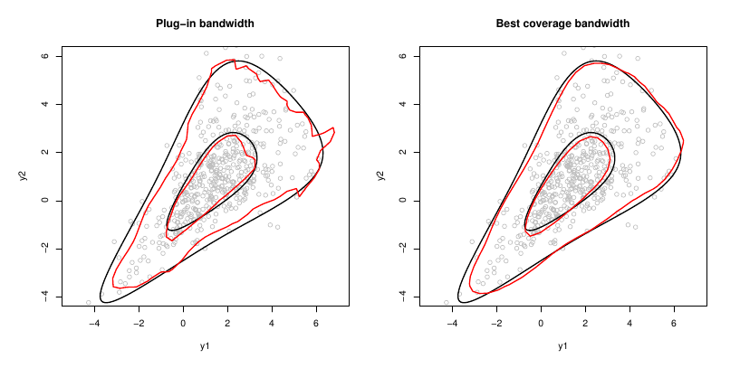

Figure 1: Estimated reference regions for plug-in and best coverage bandwidths for non-gaussian data. In black we represent true regions and in red the estimated ones for $\tau = 0.50, 0.95$. Best coverage bandwidth offers a smoother region than plug-in estimator.

The selection of $\bf H$ is crucial to obtain a good estimation of $\varepsilon_{\tau}$. A natural option is to use a plug-in or cross-validation bandwidth estimator, as in a density estimation problem
$$\ \underset{\textbf{H} \in \mathcal{H}}{\operatorname{arg\min} } \textsf{E}(\iint \left(\hat{f}_\textbf{H}(\varepsilon_{1},\varepsilon_{2}) - f_\textbf{H}(\varepsilon_{1},\varepsilon_{2})^{(-i)} \right)^2 d\varepsilon_{1}d\varepsilon_{2}
\label{CV} \tag{10}$$
where $\hat{f}_\textbf{H}(\varepsilon_{1},\varepsilon_{2})^{-i}$ is the estimated bivariate density function without the i-th observation. However, as we seek for a probabilistic region (i.e. a region which contains a given percentage of the multivariate data), the following selection criteria based on the region coverage is proposed
$$\hat{\lambda} = \underset{\lambda}{\operatorname{arg\min} } \left|\left(n^{-1}\sum_{i=1}^n I \{(Y_{i1},Y_{i2})\in R^{(-i)}(\textbf{X}_i)\}\right) - \tau\right|
\label{CV1} \tag{11}$$
where $\tau$ is the desired coverage and $\hat{R}_{\tau}^{(-i)}(X_i)$ is the estimated bivariate region without the i-th observation. Using this criteria the estimated region show a smoother contour and a coverage of the data points closer to the desired one $\tau$ (see Figure 1). Given the high computational cost of the regular proposed method in ((10)), a k-fold cross-validation scheme could be used instead. Moreover we simplify the minimization problem by considering $h_{11}=h_{22}$ and $h_{12}=0$.

## 3 Overview of the package

The [*refreg*](https://CRAN.R-project.org/package=refreg) package contains a set of functions for estimating a conditional reference, or uncertainty, region. Its working framework was designed so that people without a strong statistical background can use it. Indeed, only two functions need to be taken into account by the user: 1) the effects of the predictor variables on responses need to be estimated using the bivRegr function, a step that requires the user choose which variables may influence the region; 2) bivRegion needs to be applied to a bivRegr object so that the reference region can be estimated.

The `bivRegr()` function has the following structure:

`bivRegr(f = formulas, data = data)`

The `f` argument contains a list of five R formulae corresponding to the additive predictors for the means, variances and correlation models shown in equation (1). Since `bivRegr()` uses `mgcv::gam()` internally, the user can estimate covariate linear and non-linear effects using `s()` operator. For instance:

```r
mu1 <- y1 ~ s(x1)
mu2 <- y2 ~ s(x1)
var1 <- ~ x2
var2 <- ~ x2
rho <- ~ s(x3)

formula = list(mu1,mu2,var1,var2,rho)
```

assumes a smooth effect of `x1` on the response means, a parametric effect of `x2` on their variances, and a smooth effect of `x3` on the response correlation.

The `bivRegion()` function is designed for non-parametrically estimating a bivariate reference region:

`bivRegion(object, tau = 0.95, bandwidth = "plug-in")`

Additionally, we defined S3 methods for these two main functions. Specifically, associated with `bivRegr` we have

- `predict.bivRegr` and `plot.bivRegr`: to predict and depict additive models results for responses’ means, variances, and their correlation.
- `summary_boot.bivRegr`: a function implementing the bootstrap inference for flexible additive models (see (9)). This function results can be depicted by applying `plot.summary_boot`.

On the other hand, we defined the following S3 methods associated to `bivRegion`:

- `summary.bivRegion`: this function evaluates the region performance on the healthy patients’ sample.
- `predict.bivRegion` and `plot.bivRegion`: these functions offer a prediction or a plot of conditional regions for a new dataset. If the argument `cond=FALSE` it evaluates the response values in the standardized scale.

In addition, we define the functions `trivRegr`, `trivRegion` and `plot.trivRegion` as an extension of the aforementioned method for a trivariate response variable. Finally, our package also contains some inner functions as `ace` (for estimating variance, and correlation models), `Hcv` (it implements equation (11) method), and `refcurve` (it implements an univariate location-scale model).

## 4 Refreg in practice

This section outlines the implemented functions of the proposed package in detail, and illustrates their use with real datasets. The first illustration is related to diabetes research, in which a reference region for the joint interpretation of two glycemia tests is calculated. In the second illustration, [*refreg*](https://CRAN.R-project.org/package=refreg) methodology is used to predict the concentrations of two air pollutants during a pollution episode. Finally, the extension of the method to higher dimensions is shown using real data.

### 4.1 Case 1: Glycemic tests for diabetes diagnosis

Diabetes is a chronic disease, the diagnosis of which is based on two glycemia tests: the fasting plasma glucose (FPG) and glycated hemoglobin (HbA1c)(American Diabetes Association 2019) tests. The multivariate interpretation of FPG and HbA1c results is desirable for two reasons: i) the results of both tests are correlated in healthy patients (Aleyassine et al. 1980), ii) a miss-match between them may be indicative of a poorer prognosis (Kim et al. 2018). Finally, it is well known that both test results are influenced by patient age (Davidson 1979; Pani et al. 2008).

The age-dependent reference region for the FPG and HbA1c tests was estimated using a sample of healthy subjects derived from the A-Estrada Glycation and Inflammation Study (AEGIS) (see (Gude et al. 2017)). A subset of this dataset is available in the package under the name “AEGIS”.

This dataset comprised 1516 subjects and 7 variables:

- id: an anonymous identifier for each subject.
- gender: a factor variable that indicates the subject’s gender with levels “male”, and “female”.
- age: the subject’s age.
- dm: a factor variable indicating a previous diabetes mellitus diagnosis with levels “no”, and “yes”.
- fpg: fasting plasma glucose concentration in mg/dL.
- hba1c: the percentage of glycated hemoglobin.
- fru: fructosamine plasma concentration.

Applying the `summary()` routine to the `aegis` dataset indicated 55% of the subjects to be female, the mean age of all 1516 subjects to be 52 years (range 18-91), and that 187 subjects (12%) had been previously diagnosed with diabetes.

```r
R> summary(aegis)
       id            gender         age          dm            fpg
Min.   :   1.0   female:838   Min.   :18.00   no :1329   Min.   : 63.00
1st Qu.: 379.8   male  :678   1st Qu.:39.00   yes: 187   1st Qu.: 82.00
Median : 758.5                Median :52.00              Median : 89.00
Mean   : 758.5                Mean   :52.58              Mean   : 94.51
3rd Qu.:1137.2                3rd Qu.:67.00              3rd Qu.:100.00
Max.   :1516.0                Max.   :91.00              Max.   :274.00

hba1c             fru
Min.   : 3.900   Min.   :119.0
1st Qu.: 5.200   1st Qu.:225.0
Median : 5.400   Median :254.0
Mean   : 5.608   Mean   :262.2
3rd Qu.: 5.700   3rd Qu.:284.0
Max.   :10.200   Max.   :700.0
```

To estimate the reference region, a subset of the patients not previously diagnosed with diabetes was define as `dm_no`. This subset sample was deemed the healthy patient sample.

```r
R> dm_no = subset(aegis,aegis$dm == "no")
R> dm_yes = subset(aegis,aegis$dm == "yes")
```

To estimate the effect of age on the final region shape, the `bivRegr()` function was used. This function implements the estimation process of the bivariate location-scale:

```r
R> mu1 = fpg ~ s(age)
R> mu2 = hba1c ~ s(age)
R> var1 = ~ s(age)
R> var2 = ~ s(age)
R> rho = ~ s(age)
R> formula = list(mu1,mu2,var1,var2,rho)
```

The first and second formulae define the additive models for the mean values of both glycemia tests. The third and fourth define the additive models for test result variability. The last formula represents the additive model that comprises the effect of age on the correlation between the results of both glycemia tests. In addition to the model formulae list, a dataset including both the test results and subject’s age must be supplied to `bivRegr()` as:

```r
R> fit = bivRegr(formula,data=dm_no)
```

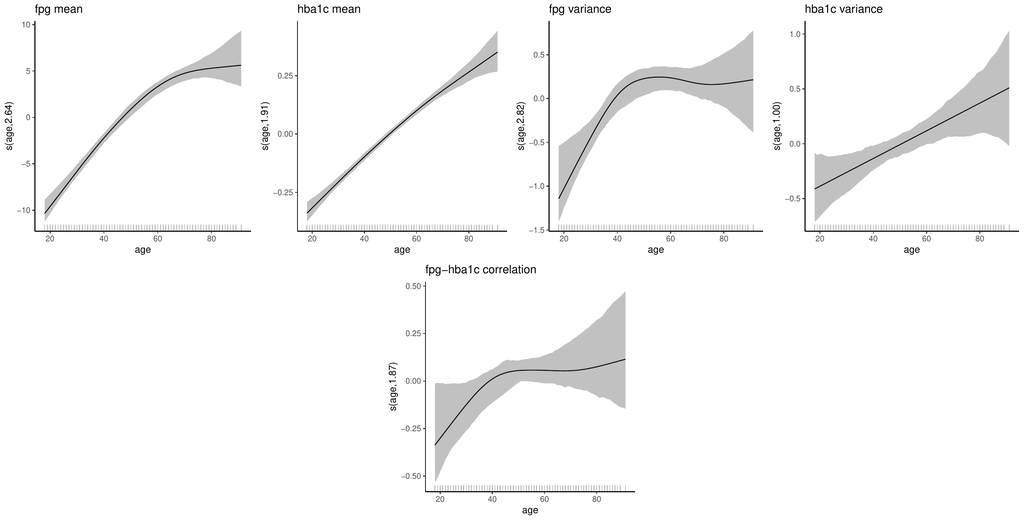

Figure 2: Estimated effects of age on the FPG and HbA1c mean, variance models, and on their correlation. Output from `summary_boot`, the shaded area is the 95% pointwise confidence interval obtained by bootstrap resampling. The parameters of our bivariate response change with age.

By applying the S3 method `plot()` to a `bivRegr` object, the estimated effects of covariates can be shown for each submodel. The argument eq= controls the model component to be represented (1 = FPG mean, 2 = HbA1c mean, 3 = FPG variance, 4 = HbA1c variance, and 5 = [FPG – HbA1c] correlation). Moreover, the function `summary_boot()` may be applied to a `bivRegr` object to obtain the 95% pointwise confidence interval for the estimated effects via bootstrapping:

```r
R> fit_boot = summary_boot(fit, B=250, parallel = TRUE )
R> plot(fit_boot,eq=1)
R> plot(fit_boot,eq=2)
R> plot(fit_boot,eq=3)
R> plot(fit_boot,eq=4)
R> plot(fit_boot,eq=5)
```

Since bootstrap resampling (introduced in equation ((9))) is time consuming, the user can fix `parallel = TRUE` and run a parallelized computation. The parallel backend is registered using [*doParallel*](https://CRAN.R-project.org/package=doParallel) (Microsoft and Weston 2020a), and the parallel computation is performed by [*foreach*](https://CRAN.R-project.org/package=foreach) (Microsoft and Weston 2020b).

[figure not shown]

Figure 3: Estimated region in the bivariate residuals scale for healthy patients (left), and patients with diabetes (right). Green contour represents the region for $\tau = 0.50$, while red dashed contour for $\tau = 0.95$.

```r
R> region = bivRegion(fit,tau=c(0.90,0.95,0.975),H_choice = "Hcov")
```

This region facilitates a multivariate interpretation of the glycemia test results. A patient whose results are “normal”, for his/her age would see them fall inside this reference region, while a subject with “abnormal” results for his/her age would not. This interpretation is possible because the model residuals are centered around zero, show unit variance, no correlation, and they are independent of age. The user can check test results located outside the reference region using the `bivRegion` S3 method `plot`:

```r
R> par(mfrow = c(1, 2))
R> plot(region, xlab = "FPG, mg/dL", ylab = "HbA1c, \%",cond=T, newdata =
 data.frame (age = c(20,30,40,50,60,70)),tau=0.95,reg.lwd=2, pch="*",col="grey")

R> plot(region,xlab = "FPG, mg/dL", ylab = "HbA1c, %",cond=T, newdata =
   data.frame(age = c(20,60)),tau=c(0.50,0.95), reg.lwd=2, pch="*", col="grey")
```

A major advantage of this representation is that it allows clinicians new insights into the subject’s glycemia status. Indeed, those patients located outside the reference region may be classified into four groups: (I) individuals with high values for both tests (first quadrant); (II) those with discordant results, with high HbA1c concentrations and low/medium FPG (second quadrant); (III) individuals with low values for both tests (third quadrant); and (IV) individuals with low/medium HbA1c concentrations and high FPG values (fourth quadrant). This distinction might be useful for physicians. For instance, discordant results are probably due to an altered bloodstream protein glycation rate, a condition associated with a poorer prognosis. Patients located outside the standardized region may be also checked applying `summary()` to a `bivRegion` object:

```r
R> summary(region,tau = 0.95)
```

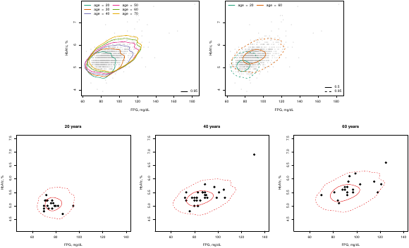

Figure 4: Predicted reference regions for different ages. Solid line contour represents the reference region for $\tau = 0.50$, and the dashed line contour for $\tau = 0.95$. Toprow plots are depicted by `plot.bivRegion` function setting the arguments `cond=TRUE` and `add=FALSE` for several ages, and bottomrow ones with `cond=TRUE` and `add=TRUE` in a pre-existing plot. The estimated regions change with age and it describes the shape of the observed data points.

The use of this region in combination with the results of the bivariate location-scale model allow the conditional reference regions to be obtained. The user can visualize these regions using the `bivRegion` S3 method `plot()`, setting `cond = TRUE` as follows:

```r
R> plot(region, xlab = "FPG, mg/dL", ylab = "HbA1c, %",cond=T, newdata = data.frame(age =
   c(20,30,40,50,60,70)),tau=0.95,reg.lwd=2, pch="*",col="grey")

R> plot(region,xlab = "FPG, mg/dL", ylab = "HbA1c, %",cond=T, newdata = data.frame(age =
   c(20,60)),tau=c(0.50,0.95),reg.lwd=2, pch="*",col="grey")
```

In addition, the region may be represented in a pre-existing plot if the `plot` function argument `add` is equal to `TRUE` as in the following code:

```r
R> plot(dm_no[dm_no$age==40,"fpg"],dm_no[dm_no$age==40,"hba1c"],main="40 years",
   xlim=c(50,140), ylim=c(4.2,7.5),xlab = "FPG, mg/dL", ylab = "HbA1c, %", pch=20,cex=2)
R> plot(region,cond=T,newdata = data.frame(age = 40),add=T,legend=F, tau=c(0.50,0.95),
   reg.lty=c(1,2))

R> plot(dm_no[dm_no$age==60,"fpg"],dm_no[dm_no$age==60,"hba1c"],main="60 years",
   xlim=c(50,140), ylim=c(4.2,7.5),xlab = "FPG, mg/dL", ylab = "HbA1c, %", pch=20,cex=2)
R> plot(region,cond=T,newdata = data.frame(age = 60),add=T,legend=F, tau=c(0.50,0.95),
   reg.lty=c(1,2))
```

In Figure 4, the bivariate reference region is shown for several ages. Note that the regions shift towards the upper right corner and expand as age increase. This agrees with the non-linear effect of age on the expected means and variability of both markers. The conditional region coverage and the performance of the methodology have already been assessed (Lado-Baleato et al. 2021).

#### Extension of case 1, conditional reference region for a trivariate response

This section provides an example of how the method proposed in equation (3) might be extended to more than two dimensions. This section is intended to provide a proof of concept rather than a formal statistical proposal. For a trivariate variable ($Y_1, Y_2, Y_3$) the following model can be assumed:
$$\left( {
\begin{array} {c}
Y_1 \\
Y_2\\
Y_3\
\end{array}
}\right) = \left( {
\begin{array} {c}
\mu_1(\textbf{X}) \\
\mu_2(\textbf{X})\\
\mu_3(\textbf{X})\
\end{array}
}\right)
+ \boldsymbol{\Sigma}^{1/2} (\textbf{X})
\left( {
\begin{array} {c}
\varepsilon_1 \\
\varepsilon_2\\
\varepsilon_3\\
\end{array}
}\right)
\label{mod3} \tag{12}$$
where $\{\mu_r(\textbf{X})\}_{r=1}^3$ represents the conditional means of each response, and $\boldsymbol{\Sigma}^{1/2} (\textbf{X})$ the Cholesky decomposition of the variance-covariance matrix
$$\boldsymbol{\Sigma} (\textbf{X})=\left({
\begin{array} {ccc}
\sigma_1^2 (\textbf{X}) & \sigma_{21} (\textbf{X})& \sigma_{31} (\textbf{X})\\
\sigma_{12} (\textbf{X}) & \sigma_2^2 (\textbf{X})& \sigma_{23} (\textbf{X}) \\
\sigma_{13} (\textbf{X}) & \sigma_{32} (\textbf{X}) & \sigma_3^2 (\textbf{X}) \\
\end{array}}\right)$$
In the trivariate case, the estimated variance-covariance matrix can be non-positive-definite. Thus, $\hat{\boldsymbol{\Sigma}}$ is modified by applying the unweighted bending method of (Schaeffer 2014) as implemented in the [*mbend*](https://CRAN.R-project.org/package=mbend) R package (Nilforooshan 2020).

Following equation ((12)), a trivariate reference region may be estimated as:
$$R_{\tau}(\textbf{X})
=
\left( {
\begin{array}{c}
\mu_1(\textbf{X}) \\
\mu_2(\textbf{X}) \\
\mu_3(\textbf{X})
\end{array}
}\right)
+
\boldsymbol{\Sigma}^{1/2} (\textbf{X}) \varepsilon_{\tau}$$
where $\varepsilon_{\tau}$ is the unconditionally probabilistic region for the errors $(\varepsilon_1,\varepsilon_2,\varepsilon_{3})$ as
$$\varepsilon_{\tau} (k) = \{(\varepsilon_1,\varepsilon_2,\varepsilon_{3}) \in{\mathbb{R}}^3 | f(\varepsilon_1,\varepsilon_2,\varepsilon_{3}) \leq k\}
\label{rexion_3} \tag{13}$$
$f$ being the density function of the trivariate residuals $(\varepsilon_1,\varepsilon_2,\varepsilon_3)$ and $k$ is the $\tau-$quantile of $f(\varepsilon_1,\varepsilon_2,\varepsilon_3)$.

Using this model, the application of the methodology for diabetes diagnosis can be extended by incorporating an additional glycemia test. This extension is justified since other glycated proteins are routinely monitored in diabetes control besides FPG and HbA1c. For instance, in conditions that determine alterations in hemoglobin metabolism (e.g., anemia or kidney disease), fructosamine (Fr) is frequently used as an additional marker. Nevertheless, the translation of Fr into average glucose levels is not as clear as for HbA1c, and discordances are often encountered between the Fr and HbA1c results. In addition, agreement among these glycemia markers can be affected by factors such as patient age.

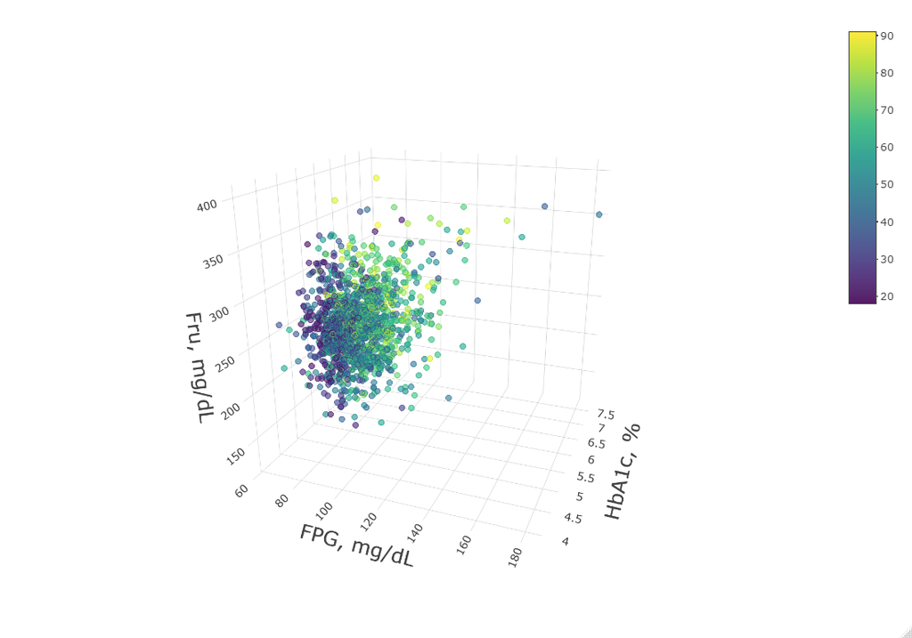

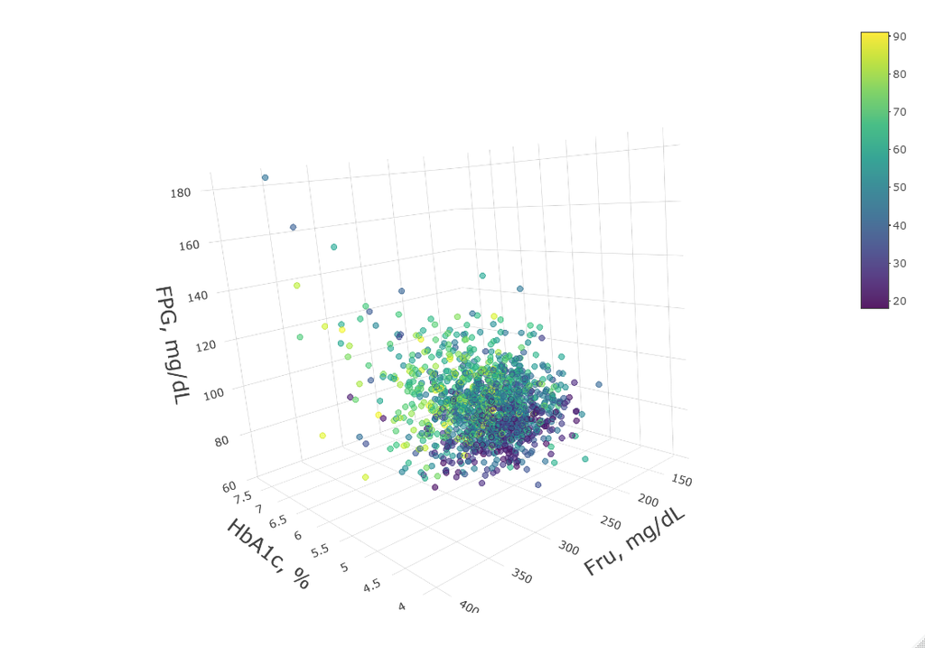

Figure 5: Scatter plot for three glycemic markers (fasting plasma glucose, glycated hemoglobin and fructosamine), with colour scale depending on age. The joint values of these glycemic markers seems to change with age, i.e., higher values are observed at higher ages. A trivariate and age-dependent reference region is desirable.

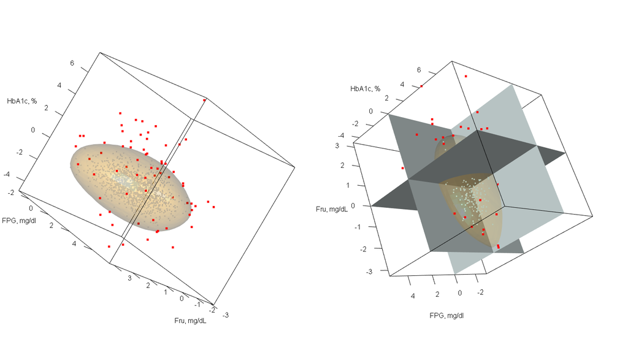

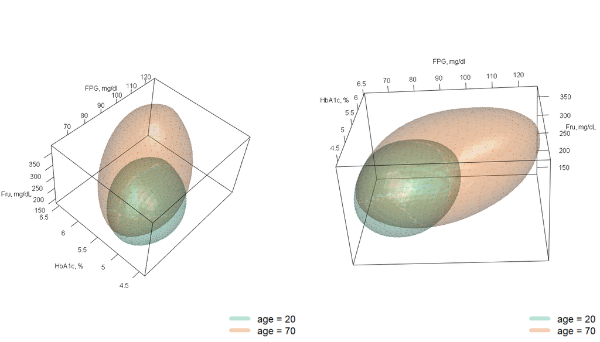

Figure 6: Standardized reference region (toprow plots), and conditional reference region (bottomrow plots), for three glycemic tests. Red points represent the trivariate values located outside the reference region after adjusting by age. The grey panels define eight octanes – each one with a different clinical profile. The trivariate reference region for these markers changes with age.

Figure 5 show the FPG, HbA1c and Fr results for the AEGIS sample. As can be seen, the values recorded for these tests correlate with one another, showing a complex multivariate distribution. Moreover, it can be appreciated how their multivariate distribution changes with age. To estimate a trivariate reference region for these markers, taking into account patient age, the `trivRegr()` function was used. This function is an extension of `bivRegr()` to the trivariate setting. The usage of both functions is similar, but additional additive predictors must be defined for the means vector and variance-covariance matrix.

```r
R> dm_no = subset(aegis,aegis$dm == "no")
R> mu1 = fpg ~ s(age)
R> mu2 = hba1c ~ s(age)
R> mu3 = fru ~ s(age)

R> var1 = ~ s(age)
R> var2 = ~ s(age)
R> var3 = ~ s(age)

R> rho12 = ~ s(age)
R> rho13 = ~ s(age)
R> rho23 = ~ s(age)

R> formula = list(mu1,mu2,mu3,var1,var2,var3,rho12,rho13,rho23)
R> fit = trivRegr(formula,data=dm\_no)
```

As in the bivariate estimation, the `trivRegion` function is applied to a `trivRegr` object. Here, the method was implemented only for a single $\tau$ (the kernel density bandwidth selection was not formally tested). The `plot()` method implemented for the `trivRegion` object can be used to interactively check the trivariate standardized and conditional reference regions:

```r
R> region = trivRegion(fit,tau=0.95)

R> plot(region,planes = F,size=5, col="red", incol = "grey",xlab="FPG, mg/dl",
   ylab="HbA1c, \%", zlab="Fru, mg/dL")
R> plot(region,planes = T,size=5,col="red",incol = "grey",xlab="FPG, mg/dl",
   ylab="HbA1c, \%", zlab="Fru, mg/dL")
R> plot(region,cond=T,newdata=data.frame(age=c(20,70)), xlab="FPG, mg/dl",
   ylab="HbA1c, \%", zlab="Fru, mg/dL", legend=T)
```

### 4.2 Case 2: beyond the medical research – Joint prediction of SO2 and NOx pollutants

This section illustrates how [*refreg*](https://CRAN.R-project.org/package=refreg) methodology can be used in fields other than laboratory medicine. It is here shown how an uncertainty region useful for the joint forecasting of the concentration of two air pollutants ($SO_2$ and $NO_x$) can be derived using the `bivRegr` and `bivRegion` functions. The following example estimates which joint $SO_2$ and $NO_x$ values are more likely in the course of a pollution episode. The data, which are contained in the package, were obtained from the surroundings of the a coal-fire power station in the northern Spain. Current Spanish legislation places a limit on the mean of 24 successive determinations of pollution concentration taken at 5 minute intervals in the neighborhood of potential point sources of pollution. Thus, access was available to historical concentrations of both air pollutants over a year, as well as several records of pollution episodes.

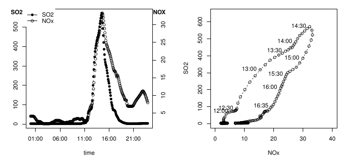

Figure 7: Two different representations of a pollution incident for $SO_2$ and $NO_x$. Left plot represent the pollution episode in the univariate scale, and rigth plot in a bivariate scale. SO$_2$ and NO$_x$ pollution episodes are associated.

```r
R > head(pollution[,1:9])
                Date      So2   Nox   So2_0  Nox_0 So2_1  Nox_1 So2_2  Nox_2
316  2003-02-07 16:15:00  38.38  2.38  73.50  3.21  76.79  3.38  81.92  3.54
1865 2003-05-07 03:10:00   3.00  3.67   3.00  3.33   3.00  3.33   3.00  3.33
1383 2003-04-04 01:35:00 256.50 11.17 293.71  8.96 294.54  8.33 285.29  7.71
3262 2003-07-09 14:35:00 225.29 17.04 104.67  7.67  84.33  6.29  64.67  4.67
1191 2003-03-30 13:55:00  42.33  4.12  80.21  4.96  84.38  5.00  88.33  5.00
3065 2003-07-04 11:50:00 145.83  8.58  99.12  5.71  83.83  5.25  70.92  4.83

R > head(pollution_episode[,1:9])
                Date  So2  Nox So2_0 Nox_0 So2_1 Nox_1 So2_2 Nox_2
1 2003-05-09 00:00:00 3.08 4.12  3.08  4.50  3.08  4.46  3.08  4.38
2 2003-05-09 00:05:00 3.08 4.12  3.08  4.46  3.08  4.50  3.08  4.46
3 2003-05-09 00:10:00 3.08 4.12  3.08  4.38  3.08  4.46  3.08  4.50
4 2003-05-09 00:15:00 3.08 4.12  3.08  4.29  3.08  4.38  3.08  4.46
5 2003-05-09 00:20:00 3.08 4.12  3.08  4.21  3.08  4.29  3.08  4.38
6 2003-05-09 00:25:00 3.08 4.12  3.08  4.12  3.08  4.21  3.08  4.29
```

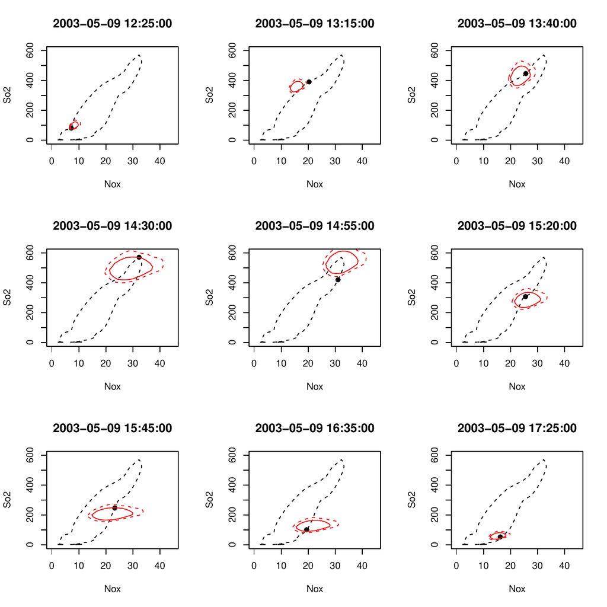

Figure 8: Estimated bivariate uncertainty region for a pollution episode. Black dashed line represents the pollution episode evolution, solid black point the observed value, and red contours the predicted uncertainty region for $\tau = 0.95$ (red solid contour) and $\tau = 0.975$ (red dashed contour).

```r
R> mu1 = Nox~s(Nox_0)+s(Nox_2)
R> mu2 = So2~s(So2_0)+s(So2_2)
R> var1 = ~s(Nox_0)+s(Nox_2)
R> var2 = ~s(So2_0)+s(So2_2)
R> rho = ~s(Nox_0)+s(So2_0)
R> f = list(mu1,mu2,var1,var2,rho)

R> fit = bivRegr(f,data=pollution)
R> region = bivRegion(fit,tau=c(0.950,0.975),shape=10)
```

```r
par(mfrow=c(3,3))
for(k in c(150, 160, 165, 175, 180, 185, 190, 200,210)){
    plot(pollution_episode[,3:2],type="l",lty=2,ylim=c(0,600),xlim=c(0,45),
    main=pollution_episode[k,1])
    points(pollution_episode[k,3:2],col="black",pch=19)
    plot(region, cond = T, newdata = pollution_episode[k,], add = T,
    tau=c(0.95, 0.975),legend=F)
}
```

## 5 Concluding remarks

This paper discusses the R implementation of a newly developed method for estimating conditional reference regions. The method was originally designed for bivariate responses to provide a joint interpretation of two glycemia markers. However, as shown with real data, the proposed package can be used in other fields, and its extension to three dimensions is feasible. The proposed package is useful in the definition of conditional reference regions for continuous diagnostic tests. Few MVRs applications are used in practice, yet they have been shown clinically valuable in the treatment of patients with cancer (Mattsson et al. 2008), cardiovascular disease (Selmeryd et al. 2018) and endocrine problems (Hoermann et al. 2016). Given the simplicity with which [*refreg*](https://CRAN.R-project.org/package=refreg) can be used, and its having no parametric restrictions, it is hoped it might enhance the use of MVRs.

The definition of a region characterizing the central part of a multivariate distribution may be of great interest in other fields. For instance, in quality control studies, multivariate control charts are commonly used when two or more attributes of a product, or process, require evaluation (Fuchs and Kenett 1998). Analogously to medical MVRs, this multivariate analysis is currently performed assuming a Gaussian distribution. Thus, the [*refreg*](https://CRAN.R-project.org/package=refreg) R package may help provide for better quality surveillance of medical conditions, environmental problems and even industrial processes that are monitored by the measurement of more than one variable.

Future versions of our package will look forward to extending our model for continuous responses of dimension higher than three. Such reference region would require a kernel density estimator for high dimension applications (Nagler 2021). To the best of our knowledge, the estimated region is not easy to visualize for scales larger than three. Although, we might identify and visualize the multivariate values located inside or outside the region using parallel coordinate plots, or the interactive visualization methods as the implemented in the [*tourr*](https://CRAN.R-project.org/package=tourr) package (Wickham et al. 2011).

## 6 Acknowledgements

Óscar Lado-Baleato is funded by a pre-doctoral grant (ED481A-2018) from the Galician Government (Plan I2C)-Xunta de Galicia. This study was also supported by grants from the Carlos III Institute of Health (Instituto de Salud Carlos III-ISCIII/PI20/01069/Co-funded by European Union), the Network for Research on Chronicity, Primary Care, and Health Promotion (Instituto de Salud Carlos III-ISCIII/RD21/0016/0022/Co-funded by European Union), and the Galician Innovation Agency-Competitive Benchmark Groups (GAIN-GRC/IN607A/2021/02/Xunta de Galicia). This article was developed under the project MTM2017-83513-R, cofinanced by the Ministry of Economy and Competitiveness (SPAIN) and by the European Regional Development Fund (FEDER). The work was also supported by the project ED431C 2020/20, approved within the framework of the Competitive Research Unit Consolidation Programme (2020), Xunta de Galicia. Work supported by the Grant PID2020-118101GB-I00, Ministerio de Ciencia e Innovación (MCIN/ AEI /10.13039/501100011033).

### 6.1 Supplementary materials

Supplementary materials are available in addition to this article. It can be downloaded at RJ-2022-029.zip

### 6.2 CRAN packages used

referenceIntervals, gamlss, tolerance, r2d2, hdrcde, distfree.cr, modQR, refreg, doParallel, foreach, mbend, tourr

### 6.3 CRAN Task Views implied by cited packages

Distributions, DynamicVisualizations, Econometrics, HighPerformanceComputing, MixedModels, NumericalMathematics

H. Aleyassine, R. Gardiner, D. Tonks and P. Koch. Glycosylated hemoglobin in diabetes mellitus: Correlations with fasting plasma glucose, serum lipids and glycosuria. *Diabetes Care.*, 3(4): 508–514, 1980.

American Diabetes Association. Classification and diagnosis of diabetes: Standards of medical care in diabetes-2019. *Diabetes Care.*, 42(Suppl 1): 13–27, 2019.

J. C. Boyd. Reference regions of two or more dimensions. *Clinical Chemistry and Laboratory Medicine (CCLM)*, 42(7): 739–746, 2004.

T. J. Cole and P. J. Green. Smoothing reference centile curves: The LMS method and penalized likelihood. *Stat Med.*, 11(10): 1305–1319, 1992.

M. B. Davidson. The effect of aging on carbohydrate metabolism: A review of the english literature and a practical approach to the diagnosis of diabetes mellitus in the elderly. *Metab Clin Exp.*, 28(6): 688–705, 1979.

J. Espasandı́n-Domı́nguez, C. Cadarso-Suárez, T. Kneib, G. Marra, N. Klein, R. Radice, O. Lado-Baleato, A. González-Quintela and F. Gude. Assessing the relationship between markers of glycemic control through flexible copula regression models. *Statistics in medicine*, 38(27): 5161–5181, 2019.

C. Fuchs and R. S. Kenett. *Multivariate quality control: Theory and applications.* CRC Press, 1998.

F. Gude, P. Dı́az-Vidal, C. Rúa-Pérez, M. Alonso-Sampedro, C. Fernández-Merino, J. Rey-Garcı́a, C. Cadarso-Suárez, M. Pazos-Couselo, J. M. Garcı́a-López and A. Gonzalez-Quintela. Glycemic variability and its association with demographics and lifestyles in a general adult population. *J Diabetes Sci Technol.*, 11(4): 780–790, 2017.

M. J. Hallworth. The ’70% claim’: What is the evidence base? *Ann Clin Biochem.*, 48(6): 487–488, 2011.

R. Hoermann, R. Larisch, J. W. Dietrich and J. E. Midgley. Derivation of a multivariate reference range for pituitary thyrotropin and thyroid hormones: Diagnostic efficiency compared with conventional single-reference method. *European journal of endocrinology*, 174(6): 735–743, 2016.

Z. Hu and R. Yang. *Distfree.cr: Distribution-free confidence region.* 2018. URL https://CRAN.R-project.org/package=distfree.cr. R package version 1.5.1.

R. J. Hyndman. *hdrcde: Highest density regions and conditional density estimation.* 2018. URL http://pkg.robjhyndman.com/hdrcde. R package version 3.3.

M. K. Kim, J. S. Jeong, J.-S. Yun, H.-S. Kwon, K. H. Baek, K.-H. Song, Y.-B. Ahn and S.-H. Ko. Hemoglobin glycation index predicts cardiovascular disease in people with type 2 diabetes mellitus: A 10-year longitudinal cohort study. *J Diabetes Complicat.*, 32(10): 906–910, 2018.

R. Koenker and G. Bassett Jr. Regression quantiles. *Econometrica.*, 46(1): 33–50, 1978.

O. Lado-Baleato, Roca-Pardiñas, C. Cadarso-Suárez and F. Gude. Modelling conditional reference regions. Application to glycemic markers. *Stat Med.*, 2021. Under Review.

A. Magnusson and J. Burgos. *r2d2: Bivariate (two-dimensional) confidence region and frequency distribution.* 2014. URL https://CRAN.R-project.org/package=r2d2. R package version 1.0-0.

A. Mattsson, D. Svensson, B. Schuett, K. J. Osterziel and M. B. Ranke. Multidimensional reference regions for IGF-i, IGFBP-2 and IGFBP-3 concentrations in serum of healthy adults. *Growth Hormone & IGF Research*, 18(6): 506–516, 2008.

Microsoft and S. Weston. *doParallel: Foreach parallel adaptor for the ’parallel’ package.* 2020a. URL https://CRAN.R-project.org/package=doParallel. R package version 1.0.16.

Microsoft and S. Weston. *Foreach: Provides foreach looping construct.* 2020b. URL https://CRAN.R-project.org/package=foreach. R package version 1.5.1.

T. Nagler. *Kdevine: Multivariate kernel density estimation with vine copulas.* 2021. URL https://CRAN.R-project.org/package=kdevine. R package version 0.4.3.

M. A. Nilforooshan. Mbend: An r package for bending non-positive-definite symmetric matrices to positive-definite. *BMC genetics*, 21(1): 1–8, 2020.

L. N. Pani, L. Korenda, J. B. Meigs, C. Driver, S. Chamany, C. S. Fox, L. Sullivan, R. B. D’Agostino and D. M. Nathan. Effect of aging on A1C levels in individuals without diabetes: Evidence from the framingham offspring study and the national health and nutrition examination survey 2001–2004. *Diabetes Care.*, 31(10): 1991–1996, 2008.

J. Roca-Pardiñas, C. Ordóñez and O. Lado-Baleato. Nonparametric location–scale model for the joint forecasting of $SO_2$ and $NO_x$ pollution episodes. *Stochastic Environmental Research and Risk Assessment*, 1–14, 2020.

L. Schaeffer. Making covariance matrices positive definite. *Center for Genetic Improvement of Livestock. http://animalbiosciences. uoguelph. ca/~ lrs/ELARES/PDforce. pdf (Accessed 1 September 2017)*, 2014.

J. Selmeryd, E. Henriksen, H. Dalen and P. Hedberg. Derivation and evaluation of age-specific multivariate reference regions to aid in identification of abnormal filling patterns: The HUNT and VaMIS studies. *JACC: Cardiovascular Imaging*, 11(3): 400–408, 2018.

M. Šiman and P. Boček. *modQR: Multiple-output directional quantile regression.* 2019. URL https://CRAN.R-project.org/package=modQR. R package version 0.1.2.

D. M. Stasinopoulos, R. A. Rigby, et al. Generalized additive models for location scale and shape (GAMLSS) in r. *Journal of Statistical Software*, 23(7): 1–46, 2007.

M. D. Stasinopoulos, R. A. Rigby, G. Z. Heller, V. Voudouris and F. De Bastiani. *Flexible regression and smoothing: Using GAMLSS in r.* CRC Press, 2017.

Y. Wei. An approach to multivariate covariate-dependent quantile contours with application to bivariate conditional growth charts. *J Am Stat Assoc.*, 103(481): 397–409, 2008.

WHO. *Multicentre growth reference study group.* World Health Organization, 2006.

H. Wickham, D. Cook, H. Hofmann and A. Buja. Tourr: An r package for exploring multivariate data with projections. *Journal of Statistical Software*, 40: 1–18, 2011.

P. Winkel and J. Lyngbye. The normal region—a multivariate problem. *Scandinavian journal of clinical and laboratory investigation*, 30(3): 339–344, 1972.

C. Winkler, K. Linden, A. Mayr, T. Schultz, T. Welchowski, J. Breuer and U. Herberg. RefCurv: A software for the construction of pediatric reference curves. *arXiv preprint arXiv:1901.09775*, 2019.

S. N. Wood. *Generalized additive models: An introduction with r.* CRC press, 2017.

E. M. Wright and P. Royston. Calculating reference intervals for laboratory measurements. *Stat Method Med Res.*, 8(2): 93–112, 1999.

D. S. Young. Tolerance: An r package for estimating tolerance intervals. *Journal of Statistical Software*, 36(i05): 2010.